# Kaplan-Meier Exploration

Playing around with Kaplain-Meier estimation of survival curve.

- Produces single curve for all the data, or subsets of the data based on variables.
- Essentially equivalent to an actuarial experience study using exposures from start to the censoring or end state

Get the test dataset. Target is week and arrest, week is the length of time, and arrest is the censoring variable. 8 predictor variables are single columns, while one variable is split out over all the 52 weeks (emp1-52).

```r
url <- "http://socserv.mcmaster.ca/jfox/Books/Companion/data/Rossi.txt"
rossi <- read.table(url, header=TRUE)
print(paste0(c("Rows: ", "Cols: "), dim(rossi)))
```

```
## [1] "Rows: 432" "Cols: 62"
```

```r
print(names(rossi))
```

```
##  [1] "week"   "arrest" "fin"    "age"    "race"   "wexp"   "mar"    "paro"
##  [9] "prio"   "educ"   "emp1"   "emp2"   "emp3"   "emp4"   "emp5"   "emp6"
## [17] "emp7"   "emp8"   "emp9"   "emp10"  "emp11"  "emp12"  "emp13"  "emp14"
## [25] "emp15"  "emp16"  "emp17"  "emp18"  "emp19"  "emp20"  "emp21"  "emp22"
## [33] "emp23"  "emp24"  "emp25"  "emp26"  "emp27"  "emp28"  "emp29"  "emp30"
## [41] "emp31"  "emp32"  "emp33"  "emp34"  "emp35"  "emp36"  "emp37"  "emp38"
## [49] "emp39"  "emp40"  "emp41"  "emp42"  "emp43"  "emp44"  "emp45"  "emp46"
## [57] "emp47"  "emp48"  "emp49"  "emp50"  "emp51"  "emp52"
```

```r
#summary(rossi[])
```

Histogram of when people either get arrested or are lost from the study.

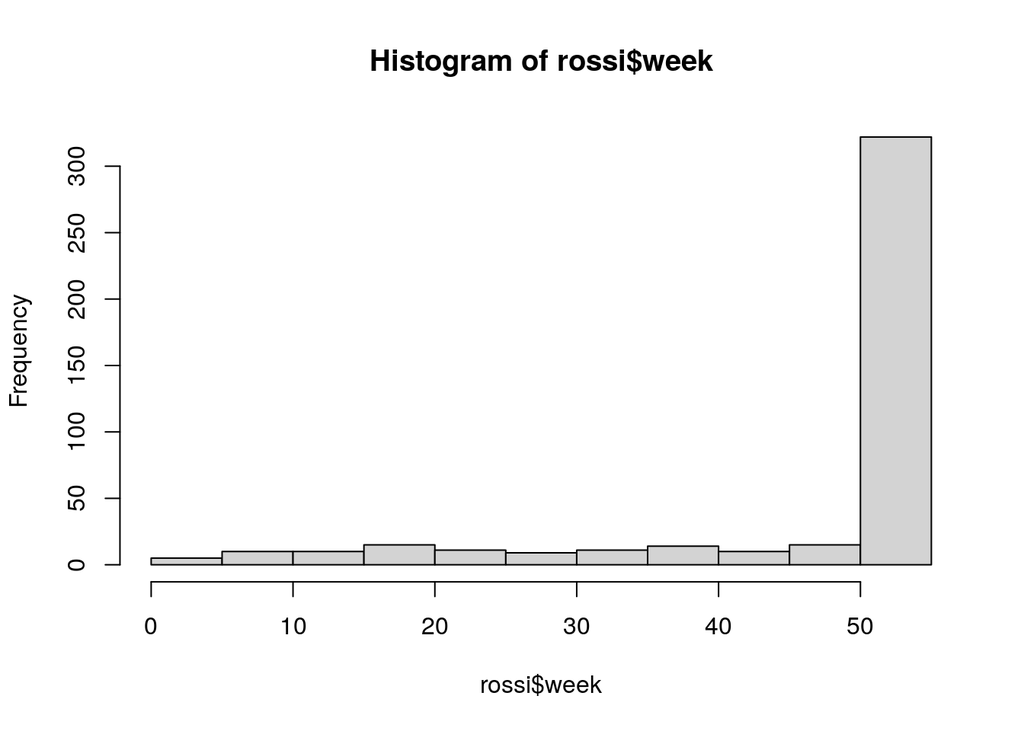

```r
hist(rossi$week)
```

Fit Kaplan-Meier with `survfit` and use a survival object as the target in the formula using `Surv(time, censor_var)`.

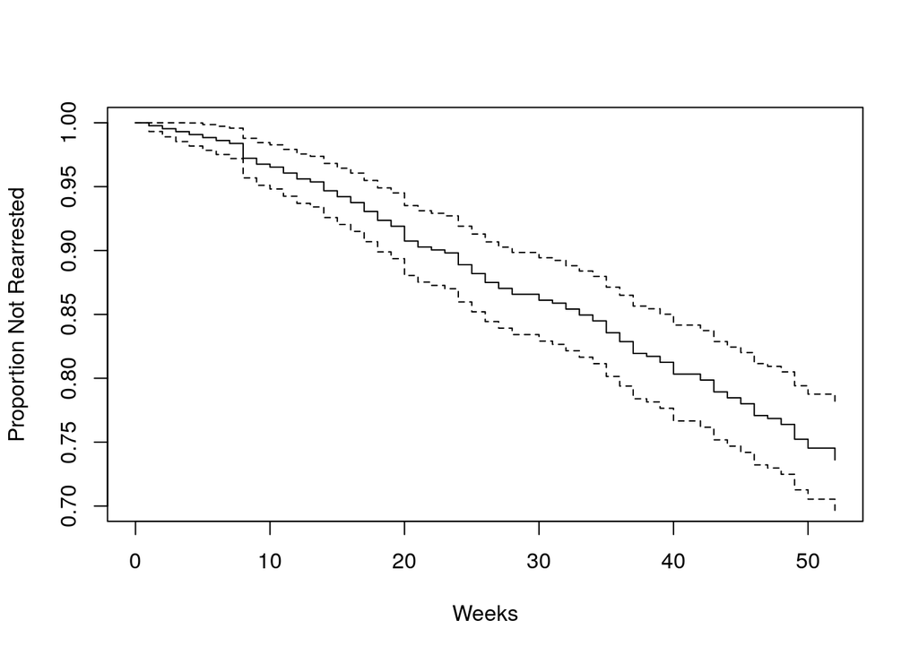

```r
km_rossi <- survfit(Surv(week, arrest) ~ 1, data = rossi)
plot(km_rossi, ylim=c(0.7, 1), xlab="Weeks", ylab="Proportion Not Rearrested")
```

Access the estimated survival function using `$surv`. Calculations below show the hazard at each time. Similar to a life insurance q from a mortality table.

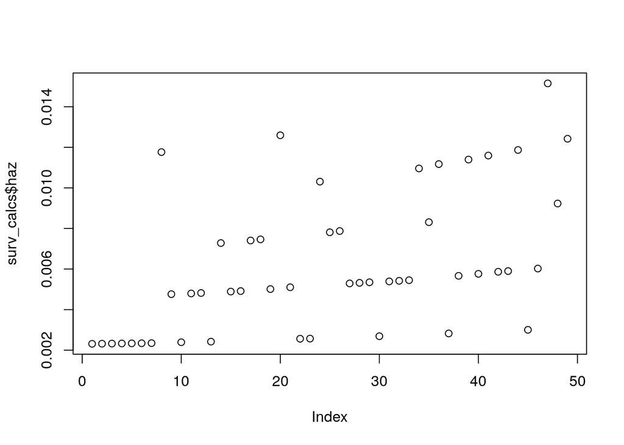

```r
surv_calcs <- tibble("surv" = km_rossi$surv,
                     "surv_lag" = dplyr::lag(km_rossi$surv, default = 1))

surv_calcs <- surv_calcs %>%
  mutate(haz = 1 - (surv / surv_lag))

plot(surv_calcs$haz)
```

Change the formula to have the Kaplan-Meier plot split by any of the variables.

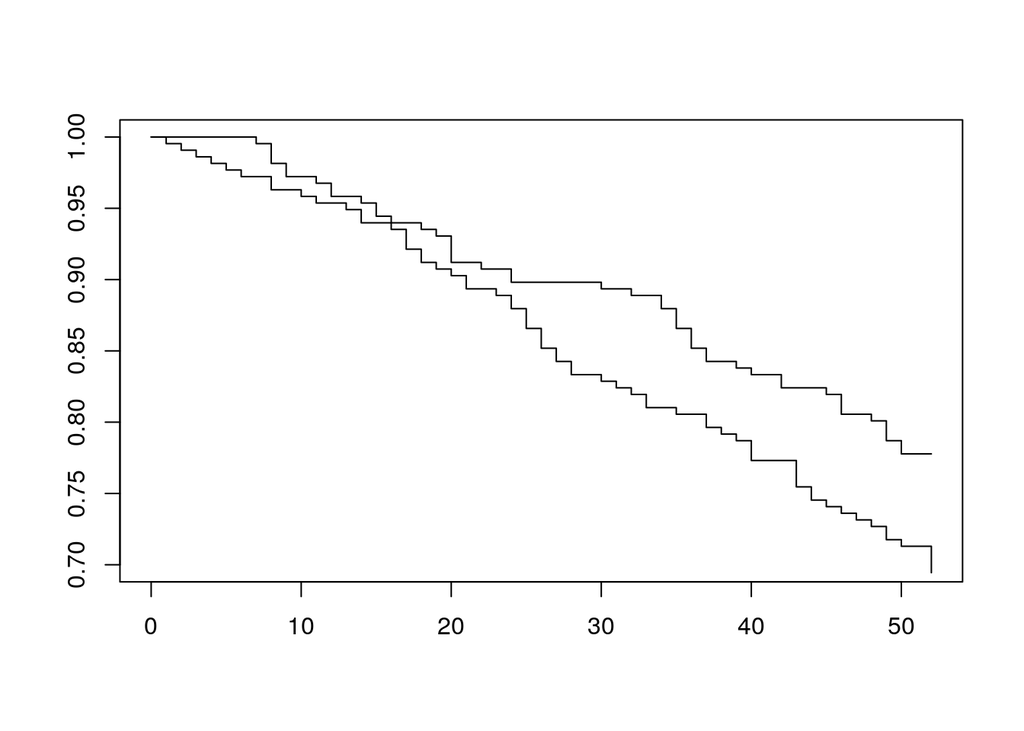

```r
survfit(Surv(week, arrest) ~ fin, data = rossi) %>%
plot(., ylim=c(0.7, 1))
```

Tried using `survminer::ggsurvplot` which gives a better output plot but it encounters some error. Seems to be missing at least one value at the end.

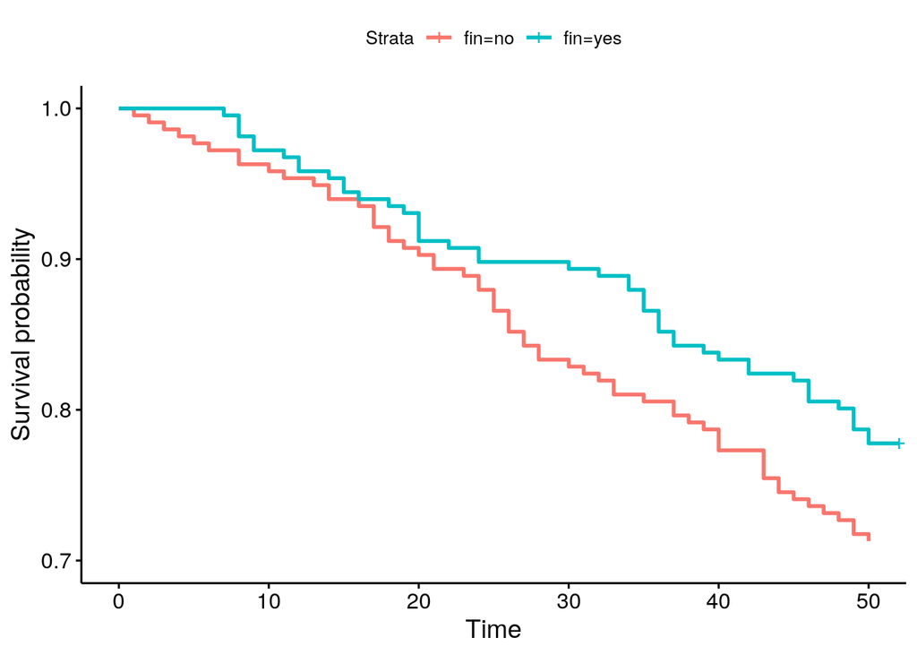

```r
survfit(Surv(week, arrest) ~ fin, data = rossi) %>%
ggsurvplot(., ylim=c(0.7, 1))
```